# HW7

Parnian kassraie - 93111185

November 18, 2016

```r
library(dplyr)
library(highcharter)
library(magrittr)
library(mosaic)
library(ggplot2)
library(psych)
library(tidyr)

death = read.csv("data/murder_suicide.csv")
```

## 1. Ploting The Variables

First one tries to show some relation between the Manner of Death and the Condition of death, such as the deceased activity, place of death, cause of death and so on.

Second one is plotted to show the relation between the personal information of the deceased and the manner of death.

```r
#Preparing the Data
death %>% filter(PlaceOfInjury<9) %>%
  filter(ActivityCode<9)->test

require(car)
# Scatterplot Matrices
scatterplotMatrix(~MannerOfDeath+ActivityCode+PlaceOfInjury+Icd10Code+InjuryAtWork+Aut, data=test,
                  spread=FALSE,
                  main="Manner, Activity, Place, Cause")

death %>%  filter(AgeRecode27<27,Education2003Revision<9,MaritalStatus != "U") ->test
scatterplotMatrix(~MannerOfDeath+AgeRecode27+Education2003Revision+Sex+MaritalStatus,data = test,
                  spread = F,
                  main = "Manner, Age, Education, Gender, Marital Status")
```

[output not shown]

## 2. Cross Correlation Plots

Couple of the variables, such as flag variables are removed for the correlation to be taken over meaningful ones.

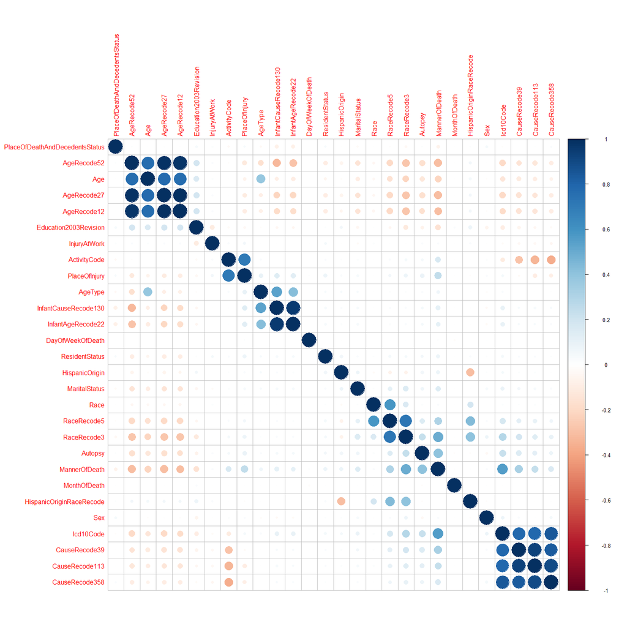

```r
require(corrplot)

death$MaritalStatus=as.integer(death$MaritalStatus)
death$Sex = as.integer(death$Sex)
death$Autopsy = as.integer(death$Autopsy)
death$InjuryAtWork = as.integer(death$InjuryAtWork)
death$Icd10Code = as.integer(death$Icd10Code)


M=cor(death[c(2,4,6:9,11:17,19,20,22:29,32,35:38)])
corrplot(M,order = "AOE")
```

We can see that the Age recodes and cause recodes are highly correlated. It is quite interesting to see that the place of injury and the deceased activity code are highly correlated as well!

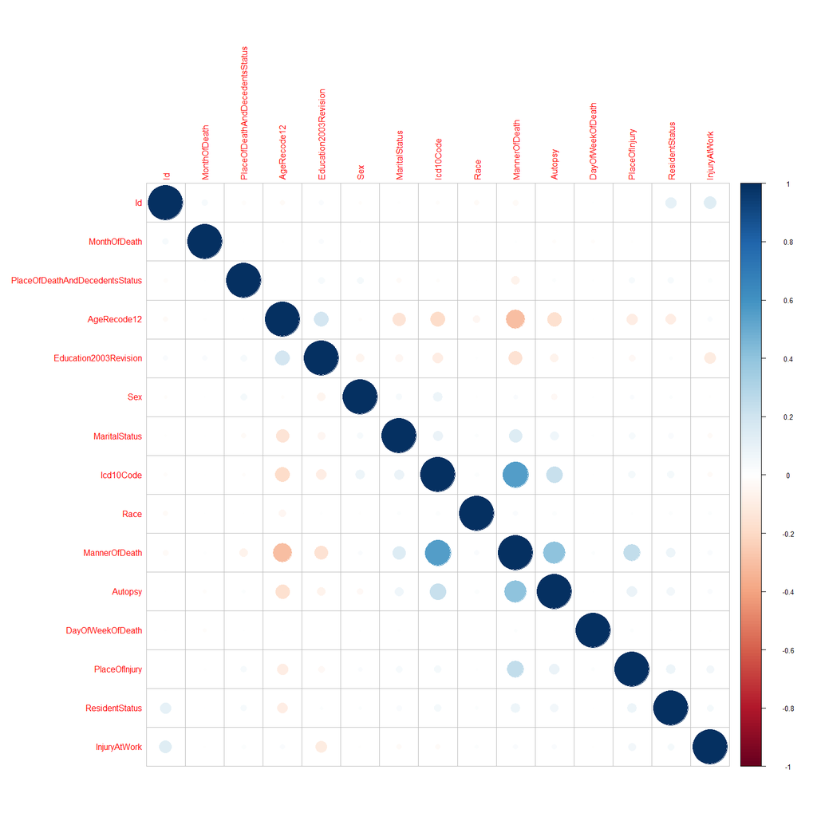

```r
death2 = death[-c(3,5,8,9,10,11,12,14,18,21,23,26,27,28,29,30,31,33,34,35,36,37,38)]
M = cor(death2)
corrplot(M,order = "AOE")
```

## 3. Effect of Race, Gender, Education, Age on Manner Of Death

### Race

Since the majority of american citizens are either white or black, Most cases of homicide or suicide belong to the white people.

```r
death2 = death[-c(3,5,8,9,10,11,12,14,18,21,23,26,27,28,29,30,31,33,34,35,36,37,38)]
Race <- read.csv("data/Race.csv")

death2<- merge(death2,by.x = "Race",Race,by.y = "Code")
drops <- c("Race")
death2 <- death2[ , !(names(death2) %in% drops)]
colnames(death2)[15] <- "Race"

death2 %>% group_by(MannerOfDeath,Race) %>%
  summarise(count = n())->death3
N_s=sum(filter(death3,MannerOfDeath==2)$count)
N_h=sum(filter(death3,MannerOfDeath==3)$count)
death3 %>% mutate(percentage = ifelse(MannerOfDeath==2,count/N_s,count/N_h)) %>%
  mutate(Death = ifelse(MannerOfDeath==2,"Suicide","Homicide"))->death3

hchart(death3,"column",x=Race,y = percentage, group = Death) %>%
  hc_add_theme(hc_theme_economist())
```

[interactive chart not shown]

The difference between Suicide rate is so high that taking a statistical test seems redundant. But let’s see if there’s a significant difference between number of homicide victims between black and white races.

Manner of Death is an ordinal variable, so we’ll be taking a wilcoxon test as follows.

$H_0$: The Number of Homicide Victims is the same between Black and white races.

```r
death3 <- filter(death2, Race %in% c("White","Black"),MannerOfDeath == 3)
wilcox.test(as.integer(death3$Race))
```

```
##
##  Wilcoxon signed rank test with continuity correction
##
## data:  as.integer(death3$Race)
## V = 131490000, p-value < 2.2e-16
## alternative hypothesis: true location is not equal to 0
```

Thus, The null hypothesis is rejected and we conclude that:

- The Suicide is more common amongst white people, how ever, african americans are the majority of homicide victims.

### Gender

It can be seen that both most of the people who commit suicide and most of the homicide victims are men.

```r
death2 %>% group_by(MannerOfDeath,Sex) %>%
  summarise(count = n())->death3
N_s=sum(filter(death3,MannerOfDeath==2)$count)
N_h=sum(filter(death3,MannerOfDeath==3)$count)
death3 %>% mutate(percentage = ifelse(MannerOfDeath==2,count/N_s,count/N_h)) %>%
  mutate(Death = ifelse(MannerOfDeath==2,"Suicide","Homicide")) %>%
  mutate(Gender = ifelse(Sex==1,"Female","Male"))->death3

hchart(death3,"column",x=Gender ,y = percentage, group = Death) %>%
  hc_add_theme(hc_theme_economist())
```

[interactive chart not shown]

The difference between Genders is highly significant, but we’ll take a test anyways.

Manner of Death and gender are both ordinal variable, so we’ll be taking a chi-squared test as follows.

$H_0$: Manner of Death is independant of Gender.

```r
tbl <- table(death2$MannerOfDeath,death2$Sex)
tbl
```

```
##
##         1     2
##   2  9776 33363
##   3  3504 13336
```

```r
chisq.test(tbl)
```

```
##
##  Pearson's Chi-squared test with Yates' continuity correction
##
## data:  tbl
## X-squared = 24.044, df = 1, p-value = 9.417e-07
```

the independence hypothesis is rejected and thus, It matter’s whether the deceased is a Female or a Male.

### Education

Each bar in the plot below, show’s the percentage of that Educational group in either homicide stats or suicide.

```r
Edu <- read.csv("data/Education2003Revision.csv")

death2<- merge(death2,by.x = "Education2003Revision",Edu,by.y = "Code")
drops <- c("Education2003Revision")
death2 <- death2[ , !(names(death2) %in% drops)]
colnames(death2)[15] <- "Education"

death2 %>% group_by(MannerOfDeath,Education) %>%
  summarise(count = n())->death3
N_s=sum(filter(death3,MannerOfDeath==2)$count)
N_h=sum(filter(death3,MannerOfDeath==3)$count)
death3 %>% mutate(percentage = ifelse(MannerOfDeath==2,count/N_s,count/N_h)) %>%
  mutate(Death = ifelse(MannerOfDeath==2,"Suicide","Homicide"))->death3

hchart(death3,"column",x=Education,y = percentage, group = Death) %>%
  hc_add_theme(hc_theme_economist())
```

[interactive chart not shown]

Similar to Gender, we’ll check whether Manner of death is independent from Education.

```r
tbl <- table(death2$MannerOfDeath,death2$Education)
tbl
```

```
##
##     8th grade or less 9 - 12th grade, no diploma Associate degree
##   2              1579                       4622             2857
##   3              1500                       3809              591
##
##     Bachelor's degree Doctorate or professional degree
##   2              4754                              735
##   3               554                               57
##
##     high school graduate or GED completed Master's degree
##   2                                 15356            1618
##   3                                  6400             169
##
##     some college credit, but no degree Unknown
##   2                               6726     776
##   3                               1890     386
```

```r
chisq.test(tbl)
```

```
##
##  Pearson's Chi-squared test
##
## data:  tbl
## X-squared = 3552.8, df = 8, p-value < 2.2e-16
```

Thus, There is a significant difference between the number of deceased people from each of these Educational Levels.

### Age

In the Plot Below it can be seen the what percentage of suicide rates or homicide rates belongs to each age interval. For example, about 25% of the homicide victims belong to the age band 15-24.

```r
Age <- read.csv("data/AgeRecode12.csv")

death2<- merge(death2,by.x = "AgeRecode12",Age,by.y = "Code")
drops <- c("AgeRecode12")
death2 <- death2[ , !(names(death2) %in% drops)]
colnames(death2)[15] <- "Age"

death2 %>% group_by(MannerOfDeath,Age) %>%
  summarise(count = n())->death3
N_s=sum(filter(death3,MannerOfDeath==2)$count)
N_h=sum(filter(death3,MannerOfDeath==3)$count)
death3 %>% mutate(percentage = ifelse(MannerOfDeath==2,count/N_s,count/N_h)) %>%
  mutate(Death = ifelse(MannerOfDeath==2,"Suicide","Homicide"))->death3

hchart(death3,"column",x=Age,y = percentage, group = Death) %>%
  hc_add_theme(hc_theme_economist())
```

[interactive chart not shown]

Manner of Death and age band are both ordinal variable, so we’ll be taking a chi-squared test as follows.

$H_0$: Manner of Death is independant of Age band.

```r
tbl <- table(death2$MannerOfDeath,death2$Age)
tbl
```

```
##
##     1 - 4 years 15 - 24 years 25 - 34 years 35 - 44 years 45 - 54 years
##   2           0          4640          5992          6097          8026
##   3         339          3972          3995          2531          1900
##
##     5 - 14 years 55 - 64 years 65 - 74 years 75 - 84 years
##   2          383          6863          3745          2179
##   3          272          1166           530           270
##
##     85 years and over Age not stated
##   2              1091              7
##   3               121              8
##
##     Under 1 year (includes not stated infant ages)
##   2                                              0
##   3                                            252
```

```r
chisq.test(tbl)
```

```
##
##  Pearson's Chi-squared test
##
## data:  tbl
## X-squared = 5847.3, df = 11, p-value < 2.2e-16
```

the independence hypothesis is rejected and thus, The age of the deceased matters.

## 4. Logistic Regression

The column **Predicted** shows the probability of MannerOfDeath being equal to 1, meaning that the cause of death is homicide.

The column **Compare** shows whether the prediction and the actual result are the same.

In the code below, we test the model for 10 different training/testing pairs, and the average of their accuracy rate is later taken as the Accuracy rate of the model.

```r
#Separating training and test data:

death2 = death[-c(3,5,8,9,10,11,12,14,18,21,23,26,27,28,29,30,31,33,34,35,36,37,38)]
death2 %>% mutate(MannerOfDeath = ifelse(MannerOfDeath==2, 0,1))->death2

accuracyrate = double()

for (i in 1:10){
Y = shuffle(death2$Id,replace = F)
Tr = Y[1:round(length(Y)/5)]
Te = Y[round(length(Y)/5)+1:length(Y)]
training <- filter(death2, Id %in% Tr)
testing <- filter(death2, Id %in% Te )


#Applying a logistic model on the training data:
fit <- glm(MannerOfDeath~., family = binomial(link = "logit"), training)

#Removing the variables with the same meaning:

fit2 <- glm(MannerOfDeath~.-Race-InjuryAtWork,family = "binomial",training)


#applying on test data and calculating the error:


testing[,"predicted"] <- predict(fit2,newdata = testing , type = "response")


testing %>% mutate(Result = ifelse(predicted>0.5, "Homicide","Suicide")) %>%
  mutate(MannerOfDeath = ifelse(MannerOfDeath == "0", "Suicide","Homicide"))->testing

# Now let's calculate the accuracy rate.
testing %>% mutate( Compare = ifelse(MannerOfDeath==Result , 1, 0))->testing
accuracyrate[i] = round(sum(testing$Compare)/length(testing$Compare),4)*100

}

AccuracyRate = round(mean(accuracyrate),2)
```

The classifier can classify the data with a $98.56%$ accuracy rate! Here’s the summary of the model:

```r
summary(fit2)
```

```
##
## Call:
## glm(formula = MannerOfDeath ~ . - Race - InjuryAtWork, family = "binomial",
##     data = training)
##
## Deviance Residuals:
##     Min       1Q   Median       3Q      Max
## -6.7884  -0.3203  -0.1096   0.1065   8.4904
##
## Coefficients:
##                                  Estimate Std. Error z value Pr(>|z|)
## (Intercept)                    -4.561e+01  9.232e-01 -49.408  < 2e-16 ***
## Id                             -9.875e-08  4.778e-08  -2.067 0.038749 *
## ResidentStatus                 -8.604e-02  6.338e-02  -1.358 0.174590
## Education2003Revision          -1.215e-01  2.051e-02  -5.925 3.13e-09 ***
## MonthOfDeath                    9.731e-03  1.087e-02   0.895 0.370564
## Sex                            -2.989e-01  8.992e-02  -3.324 0.000887 ***
## AgeRecode12                    -2.173e-01  2.166e-02 -10.034  < 2e-16 ***
## PlaceOfDeathAndDecedentsStatus -1.322e-01  1.748e-02  -7.565 3.89e-14 ***
## MaritalStatus                   1.484e-01  4.050e-02   3.663 0.000249 ***
## DayOfWeekOfDeath                4.283e-03  1.839e-02   0.233 0.815819
## Autopsy                         1.427e+00  9.072e-02  15.733  < 2e-16 ***
## PlaceOfInjury                   1.608e-01  4.794e-03  33.546  < 2e-16 ***
## Icd10Code                       1.894e-01  3.814e-03  49.666  < 2e-16 ***
## ---
## Signif. codes:  0 '***' 0.001 '**' 0.01 '*' 0.05 '.' 0.1 ' ' 1
##
## (Dispersion parameter for binomial family taken to be 1)
##
##     Null deviance: 14226.4  on 11995  degrees of freedom
## Residual deviance:  5150.7  on 11983  degrees of freedom
## AIC: 5176.7
##
## Number of Fisher Scoring iterations: 8
```

## 5. Comparing the Results

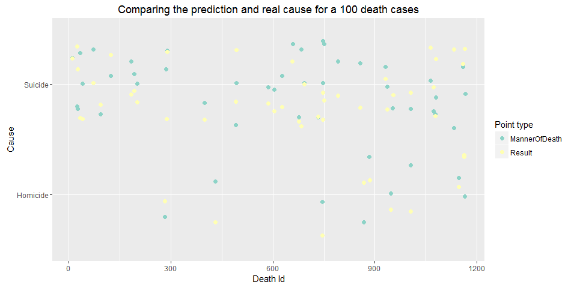

```r
testing %>% gather("Outcome","Manner",c(11,17))->ploting

ploting = ploting[order(ploting$Id),]
ploting = ploting[1:100,]
ggplot(ploting,aes(x=ploting$Id,y=ploting$Manner,color=ploting$Outcome)) +
  geom_point(position = "jitter",size=rel(2))+
  scale_color_brewer(palette = "Set3",name ="Point type")+
  labs(x="Death Id",y="Cause",title="Comparing the prediction and real cause for a 100 death cases")
```

[figure not shown]

```r
testing %>% mutate(Compare = ifelse(Compare=="0", "Correct","False"))->testing
ggplot(testing,aes(testing$MannerOfDeath,testing$Result,color = testing$Compare))+
  geom_point(position="jitter")+
  scale_color_manual(values = c("Indianred1","Royalblue"),name="Prediction")+
  labs(x="Reason of Death",y="Prediction",title="Comparing the prediction and real cause for all points")
```

## 6. Maximal Model

#### Step 1: Preparing the test and training data:

We should make sure that we’re removing all the columns with the same meaning as *Manner Of Death* such as CauseRecode Variables, since they restate the cause of death.

```r
#preparing test and training Data
death2 = death[-c(3,5,8,9,10,11,12,14,18,21,23,26,27,28,29,30,31,33,34,35,36,37,38)]
death2 %>% mutate(MannerOfDeath = ifelse(MannerOfDeath==2, 0,1))->death2

Y = shuffle(death2$Id,replace = F)
Tr = Y[1:round(length(Y)/5)]
Te = Y[round(length(Y)/5)+1:length(Y)]
training <- filter(death2, Id %in% Tr)
testing <- filter(death2, Id %in% Te )
```

#### Step 2: Creating the Subsets:

```r
Cols = colnames(death2)
Cols = Cols[3:15]
X=1:13
func <- function(x){
  return(combn(Cols,x))
}
list = lapply(X,func)
```

#### Step 3: Creating the function that calculates accuracyrate:

```r
AccRate <- function(vec){

b <- paste(vec, collapse =" + ")
f<- paste("MannerOfDeath ~ ",b,sep = "")
fitMaximal <- glm(as.formula(f),training,family ="binomial")

testing[,"predicted"] <- predict(fitMaximal,newdata = testing , type = "response")

testing %>% mutate(Result = ifelse(predicted>0.5, "Homicide","Suicide")) %>%
  mutate(MannerOfDeath = ifelse(MannerOfDeath == "0", "Suicide","Homicide"))->testing

# Now let's calculate the accuracy rate.
testing %>% mutate( Compare = ifelse(MannerOfDeath==Result , 1, 0))->testing
accuracyrate = round(sum(testing$Compare)/length(testing$Compare),4)*100
return(accuracyrate)
}
```

#### Step 4: applying the function to some selected subsets:

The following code iterates over all the subsets and returns their Accuracy Rate, However, it will take about 2-3 hour to run.

```r
I = 1:length(list)

  for (i in I){
    End = factorial(length(list))/(factorial(13-i)*factorial(i))
    for(j in 1:End){
      vec = list[[i]][,j]
      AccRate(vec)
    }
  }
```

instead, I’ll run the code over 65 random subsets with different sizes:

```r
AR = matrix(nrow = 5,ncol = 13)
Vec = matrix(nrow = 5,ncol = 13)
I = 1:length(list)
for (i in I){
  End = factorial(length(list))/(factorial(13-i)*factorial(i))
  J <- round(runif(5, 1, End))
  ind = 1
  for(j in J){
  vec = list[[i]][,j]
  AR[ind,i] = AccRate(vec)
  #Vec[ind,i] = f
  ind=ind+1
    }
}

AR
```

```
##       [,1]  [,2]  [,3]  [,4]  [,5]  [,6]  [,7]  [,8]  [,9] [,10] [,11]
## [1,] 71.83 71.83 73.70 74.16 98.82 75.81 98.51 98.70 98.71 98.67 98.49
## [2,] 73.70 72.62 73.69 98.67 98.95 76.58 98.72 98.48 76.37 98.65 98.47
## [3,] 71.83 98.92 73.70 71.83 98.82 75.40 98.67 73.07 98.72 98.44 76.36
## [4,] 71.83 98.67 75.84 70.88 98.68 72.63 78.13 98.51 98.48 98.49 76.36
## [5,] 71.83 72.66 74.53 73.94 98.96 75.48 98.48 98.51 98.50 98.45 98.61
##      [,12] [,13]
## [1,] 98.41 98.46
## [2,] 98.65 98.46
## [3,] 98.47 98.46
## [4,] 98.41 98.46
## [5,] 98.27 98.46
```

it can be seen that the sets includeing the “Icd10Code” Column have higher accuracy rates.

#### Step 5: Finding the Maximal Model

after running the algorithm above a couple of times, i derived the formula used below.

```r
f="MannerOfDeath~Education2003Revision+Sex+AgeRecode12+MaritalStatus+Icd10Code+PlaceOfInjury+Race+PlaceOfDeathAndDecedentsStatus"
fitMaximal <- glm(as.formula(f),training,family = "binomial")
summary(fitMaximal)
```

```
##
## Call:
## glm(formula = as.formula(f), family = "binomial", data = training)
##
## Deviance Residuals:
##     Min       1Q   Median       3Q      Max
## -7.3807  -0.2928  -0.1865   0.0571   8.4904
##
## Coefficients:
##                                  Estimate Std. Error z value Pr(>|z|)
## (Intercept)                    -51.316800   0.991332 -51.766  < 2e-16 ***
## Education2003Revision           -0.108291   0.021592  -5.015 5.29e-07 ***
## Sex                             -0.275109   0.092691  -2.968 0.002997 **
## AgeRecode12                     -0.233909   0.022562 -10.367  < 2e-16 ***
## MaritalStatus                    0.143709   0.043552   3.300 0.000968 ***
## Icd10Code                        0.230760   0.004185  55.142  < 2e-16 ***
## PlaceOfInjury                    0.189085   0.005384  35.121  < 2e-16 ***
## Race                             0.005816   0.005431   1.071 0.284227
## PlaceOfDeathAndDecedentsStatus  -0.142857   0.017787  -8.032 9.63e-16 ***
## ---
## Signif. codes:  0 '***' 0.001 '**' 0.01 '*' 0.05 '.' 0.1 ' ' 1
##
## (Dispersion parameter for binomial family taken to be 1)
##
##     Null deviance: 14157.8  on 11995  degrees of freedom
## Residual deviance:  4839.4  on 11987  degrees of freedom
## AIC: 4857.4
##
## Number of Fisher Scoring iterations: 19
```

[figure not shown]

```r
testing[,"predicted"] <- predict(fitMaximal,newdata = testing , type = "response")

testing %>% mutate(Result = ifelse(predicted>0.5, "Homicide","Suicide")) %>%
  mutate(MannerOfDeath = ifelse(MannerOfDeath == "0", "Suicide","Homicide"))->testing

# Now let's calculate the accuracy rate.
testing %>% mutate( Compare = ifelse(MannerOfDeath==Result , 1, 0))->testing
accuracyrate = round(sum(testing$Compare)/length(testing$Compare),4)*100

testing %>% mutate(Compare = ifelse(Compare=="0", "Correct","False"))->testing
ggplot(testing,aes(testing$MannerOfDeath,testing$Result,color = testing$Compare))+
  geom_point(position="jitter")+
  scale_color_manual(values = c("Indianred1","Royalblue"),name="Prediction")+
  labs(x="Reason of Death",y="Prediction",title="Comparing the prediction and real cause for all points")
```

## 7. Two New Methods for Prediction

I did not understand this part.